# R Notebook

Spotify top 50 in 2021

Data Set Info -track: The Name of the track.

-artist: The Name of the Artist.

-danceability: Danceability describes how suitable a track is for dancing based on a combination of musical elements including tempo, rhythm stability, beat strength, and overall regularity. A value of 0.0 is least danceable and 1.0 is most danceable.

- energy: Energy is a measure from 0.0 to 1.0 and represents a perceptual measure of intensity and activity. Typically, energetic tracks feel fast, loud, and noisy. For example, death metal has high energy, while a Bach prelude scores low on the scale. Perceptual features contributing to this attribute include dynamic range, perceived loudness, timbre, onset rate, and general entropy.
- key: The estimated overall key of the track. Integers map to pitches using standard Pitch Class notation. E.g. 0 = C, 1 = C?/D?, 2 = D, and so on. If no key was detected, the value is -1.
- loudness: The overall loudness of a track in decibels (dB). Loudness values are averaged across the entire track and are useful for comparing relative loudness of tracks. Loudness is the quality of a sound that is the primary psychological correlate of physical strength (amplitude). Values typical range between -60 and 0 db.
- mode: Mode indicates the modality (major or minor) of a track, the type of scale from which its melodic content is derived. Major is represented by 1 and minor is 0.
- speechiness: Speechiness detects the presence of spoken words in a track. The more exclusively speech-like the recording (e.g. talk show, audio book, poetry), the closer to 1.0 the attribute value. Values above 0.66 describe tracks that are probably made entirely of spoken words. Values between 0.33 and 0.66 describe tracks that may contain both music and speech, either in sections or layered, including such cases as rap music. Values below 0.33 most likely represent music and other non-speech-like tracks.
- acousticness: A confidence measure from 0.0 to 1.0 of whether the track is acoustic. 1.0 represents high confidence the track is acoustic.
- instrumentalness: Predicts whether a track contains no vocals. “Ooh” and “aah” sounds are treated as instrumental in this context. Rap or spoken word tracks are clearly “vocal”. The closer the instrumentalness value is to 1.0, the greater likelihood the track contains no vocal content. Values above 0.5 are intended to represent instrumental tracks, but confidence is higher as the value approaches 1.0.
- liveness: Detects the presence of an audience in the recording. Higher liveness values represent an increased probability that the track was performed live. A value above 0.8 provides strong likelihood that the track is live.
- valence: A measure from 0.0 to 1.0 describing the musical positiveness conveyed by a track. Tracks with high valence sound more positive (e.g. happy, cheerful, euphoric), while tracks with low valence sound more negative (e.g. sad, depressed, angry).
- tempo: The overall estimated tempo of a track in beats per minute (BPM). In musical terminology, tempo is the speed or pace of a given piece and derives directly from the average beat duration.
- duration_ms: The duration of the track in milliseconds.
- time_signature: An estimated overall time signature of a track. The time signature (meter) is a notational convention to specify how many beats are in each bar (or measure).

```r
#plot(cars)
library(tidyverse)
library(ggplot2)
library(dplyr)
```

```r
spotify_df = readr::read_csv("spotify_top50_2021.csv")
```

```r
spotify_df = spotify_df %>% mutate(duration_m = duration_ms/1000/60)
spotify_df = spotify_df %>% arrange(desc(popularity))
spotify_df
```

| id | artist_name | track_name | track_id | popularity | danceability | energy | key | loudness | mode | speechiness | acousticness | instrumentalness | liveness | valence | tempo | duration_ms | time_signature | duration_m |
| --- | --- | --- | --- | --- | --- | --- | --- | --- | --- | --- | --- | --- | --- | --- | --- | --- | --- | --- |
| 4 | Olivia Rodrigo | good 4 u | 4ZtFanR9U6ndgddUvNcjcG | 95 | 0.563 | 0.664 | 9 | -5.044 | 1 | 0.1540 | 0.33500 | 0.00e+00 | 0.0849 | 0.6880 | 166.928 | 178147 | 4 | 2.969117 |
| 14 | Ed Sheeran | Bad Habits | 3rmo8F54jFF8OgYsqTxm5d | 95 | 0.807 | 0.893 | 11 | -3.745 | 0 | 0.0347 | 0.04510 | 2.79e-05 | 0.3660 | 0.5370 | 126.011 | 230747 | 4 | 3.845783 |
| 43 | Doja Cat | Woman | 6Uj1ctrBOjOas8xZXGqKk4 | 95 | 0.824 | 0.764 | 5 | -4.175 | 0 | 0.0854 | 0.08880 | 2.94e-03 | 0.1170 | 0.8810 | 107.998 | 172627 | 4 | 2.877117 |
| 9 | Glass Animals | Heat Waves | 02MWAaffLxlfxAUY7c5dvx | 94 | 0.761 | 0.525 | 11 | -6.900 | 1 | 0.0944 | 0.44000 | 6.70e-06 | 0.0921 | 0.5310 | 80.870 | 238805 | 4 | 3.980083 |
| 23 | Bad Bunny | Yonaguni | 2JPLbjOn0wPCngEot2STUS | 94 | 0.644 | 0.648 | 1 | -4.601 | 1 | 0.1180 | 0.27600 | 0.00e+00 | 0.1350 | 0.4400 | 179.951 | 206710 | 4 | 3.445167 |
| 8 | The Weeknd | Blinding Lights | 0VjIjW4GlUZAMYd2vXMi3b | 93 | 0.514 | 0.730 | 1 | -5.934 | 1 | 0.0598 | 0.00146 | 9.54e-05 | 0.0897 | 0.3340 | 171.005 | 200040 | 4 | 3.334000 |
| 10 | Måneskin | Beggin' | 3Wrjm47oTz2sjIgck11l5e | 93 | 0.714 | 0.800 | 11 | -4.808 | 0 | 0.0504 | 0.12700 | 0.00e+00 | 0.3590 | 0.5890 | 134.002 | 211560 | 4 | 3.526000 |
| 40 | Doja Cat | Need to Know | 3Vi5XqYrmQgOYBajMWSvCi | 93 | 0.664 | 0.609 | 1 | -6.509 | 1 | 0.0707 | 0.30400 | 0.00e+00 | 0.0926 | 0.1940 | 130.041 | 210560 | 4 | 3.509333 |
| 1 | Olivia Rodrigo | drivers license | 5wANPM4fQCJwkGd4rN57mH | 92 | 0.561 | 0.431 | 10 | -8.810 | 1 | 0.0578 | 0.76800 | 1.42e-05 | 0.1060 | 0.1370 | 143.875 | 242013 | 4 | 4.033550 |
| 3 | The Kid LAROI | STAY (with Justin Bieber) | 5PjdY0CKGZdEuoNab3yDmX | 92 | 0.591 | 0.764 | 1 | -5.484 | 1 | 0.0483 | 0.03830 | 0.00e+00 | 0.1030 | 0.4780 | 169.928 | 141806 | 4 | 2.363433 |

[output cut: 40 more lines]

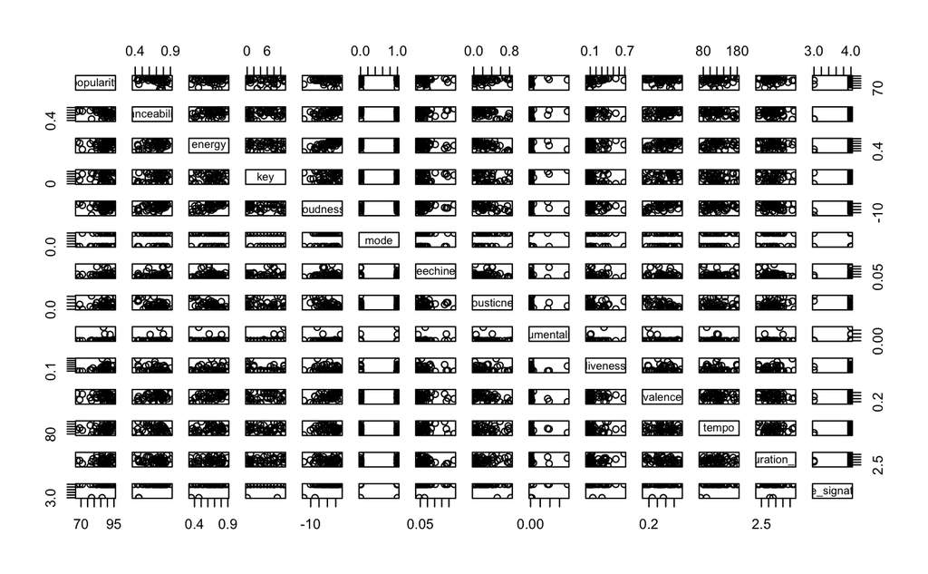

```r
spotify = spotify_df %>% select(c(popularity, danceability, energy,key,loudness,mode,speechiness,acousticness,instrumentalness,liveness,valence,tempo,duration_m,time_signature))
plot(spotify)
```

```r
summary(spotify_df)
```

```
       id        artist_name         track_name          track_id
 Min.   : 1.00   Length:50          Length:50          Length:50
 1st Qu.:13.25   Class :character   Class :character   Class :character
 Median :25.50   Mode  :character   Mode  :character   Mode  :character
 Mean   :25.50
 3rd Qu.:37.75
 Max.   :50.00
   popularity     danceability        energy            key           loudness
 Min.   :67.00   Min.   :0.3800   Min.   :0.3390   Min.   : 0.00   Min.   :-11.639
 1st Qu.:85.25   1st Qu.:0.5978   1st Qu.:0.5453   1st Qu.: 1.00   1st Qu.: -7.186
 Median :88.00   Median :0.7145   Median :0.6565   Median : 5.50   Median : -5.486
 Mean   :86.80   Mean   :0.6857   Mean   :0.6464   Mean   : 5.18   Mean   : -5.904
 3rd Qu.:90.00   3rd Qu.:0.7745   3rd Qu.:0.7648   3rd Qu.: 8.00   3rd Qu.: -4.258
 Max.   :95.00   Max.   :0.9030   Max.   :0.8930   Max.   :11.00   Max.   : -2.810
      mode       speechiness       acousticness     instrumentalness
 Min.   :0.00   Min.   :0.02840   Min.   :0.00146   Min.   :0.000e+00
 1st Qu.:0.00   1st Qu.:0.04612   1st Qu.:0.04000   1st Qu.:0.000e+00
 Median :1.00   Median :0.06315   Median :0.19600   Median :0.000e+00
 Mean   :0.62   Mean   :0.08137   Mean   :0.25381   Mean   :1.606e-03
 3rd Qu.:1.00   3rd Qu.:0.09430   3rd Qu.:0.40550   3rd Qu.:2.447e-05
 Max.   :1.00   Max.   :0.28600   Max.   :0.82700   Max.   :3.820e-02
    liveness          valence           tempo         duration_ms     time_signature
 Min.   :0.04760   Min.   :0.0823   Min.   : 72.02   Min.   :132780   Min.   :3.00
 1st Qu.:0.09323   1st Qu.:0.4015   1st Qu.: 98.66   1st Qu.:172400   1st Qu.:4.00
 Median :0.11500   Median :0.5180   Median :120.52   Median :198712   Median :4.00
 Mean   :0.18229   Mean   :0.5289   Mean   :121.08   Mean   :197488   Mean   :3.96
 3rd Qu.:0.24650   3rd Qu.:0.7063   3rd Qu.:138.53   3rd Qu.:215597   3rd Qu.:4.00
 Max.   :0.68800   Max.   :0.9580   Max.   :180.92   Max.   :287120   Max.   :4.00
   duration_m
 Min.   :2.213
 1st Qu.:2.873
 Median :3.312
 Mean   :3.291
 3rd Qu.:3.593
 Max.   :4.785
```

```r
library(ggcorrplot)
cor = cor(spotify)
cor
```

```
                    popularity danceability      energy          key      loudness
popularity        1.0000000000  -0.27565855  0.08539773 -0.006061295  0.0006904022
danceability     -0.2756585483   1.00000000  0.42410077  0.266594347  0.4669487082
energy            0.0853977281   0.42410077  1.00000000  0.020070999  0.7494753960
key              -0.0060612951   0.26659435  0.02007100  1.000000000  0.0261753106
loudness          0.0006904022   0.46694871  0.74947540  0.026175311  1.0000000000
mode              0.2404547671  -0.19492086 -0.16583462 -0.296727014  0.0685456373
speechiness      -0.0392813778   0.25846499 -0.06853985  0.119803255 -0.0090775592
acousticness      0.0688326094  -0.52470257 -0.67521949 -0.133163116 -0.6290237161
instrumentalness  0.0666012339   0.08875885 -0.09849634  0.300550549 -0.1010441177
liveness          0.1657705180  -0.23159926  0.13079600 -0.198790039 -0.0990968790
valence          -0.0687969839   0.36096233  0.51376848  0.119262565  0.5794249310
tempo             0.2099878379  -0.18591933  0.22123921 -0.111567134  0.1427572322
duration_m        0.1060710532  -0.10443295  0.06804075  0.164861659 -0.0118969946
time_signature    0.1579494379   0.38722828  0.33477612  0.036242969  0.4451590517
                        mode  speechiness acousticness instrumentalness     liveness
popularity        0.24045477 -0.039281378  0.068832609       0.06660123  0.165770518
danceability     -0.19492086  0.258464991 -0.524702566       0.08875885 -0.231599262
energy           -0.16583462 -0.068539848 -0.675219491      -0.09849634  0.130795996
key              -0.29672701  0.119803255 -0.133163116       0.30055055 -0.198790039
loudness          0.06854564 -0.009077559 -0.629023716      -0.10104412 -0.099096879
mode              1.00000000  0.033206990  0.086672892       0.04448925 -0.070091908
speechiness       0.03320699  1.000000000 -0.005744808       0.11719689 -0.015350233
acousticness      0.08667289 -0.005744808  1.000000000      -0.02866417  0.008522064
instrumentalness  0.04448925  0.117196887 -0.028664174       1.00000000  0.067491320
liveness         -0.07009191 -0.015350233  0.008522064       0.06749132  1.000000000
valence          -0.14844040 -0.049889557 -0.608243500      -0.27531124 -0.036093610
tempo             0.09784964  0.044643783 -0.101144840      -0.13595731 -0.048326976
duration_m        0.09969911 -0.267925150  0.081367824       0.10688117  0.131190801
time_signature    0.05046473  0.074212709 -0.369461033       0.03194528 -0.061661790
                     valence        tempo   duration_m time_signature
popularity       -0.06879698  0.209987838  0.106071053     0.15794944
danceability      0.36096233 -0.185919328 -0.104432953     0.38722828
energy            0.51376848  0.221239213  0.068040755     0.33477612
key               0.11926257 -0.111567134  0.164861659     0.03624297
loudness          0.57942493  0.142757232 -0.011896995     0.44515905
mode             -0.14844040  0.097849640  0.099699110     0.05046473
speechiness      -0.04988956  0.044643783 -0.267925150     0.07421271
acousticness     -0.60824350 -0.101144840  0.081367824    -0.36946103
instrumentalness -0.27531124 -0.135957313  0.106881169     0.03194528
liveness         -0.03609361 -0.048326976  0.131190801    -0.06166179
valence           1.00000000  0.012656071 -0.223436784     0.10441771
tempo             0.01265607  1.000000000 -0.009600561     0.28570593
duration_m       -0.22343678 -0.009600561  1.000000000     0.03401888
time_signature    0.10441771  0.285705928  0.034018876     1.00000000
```

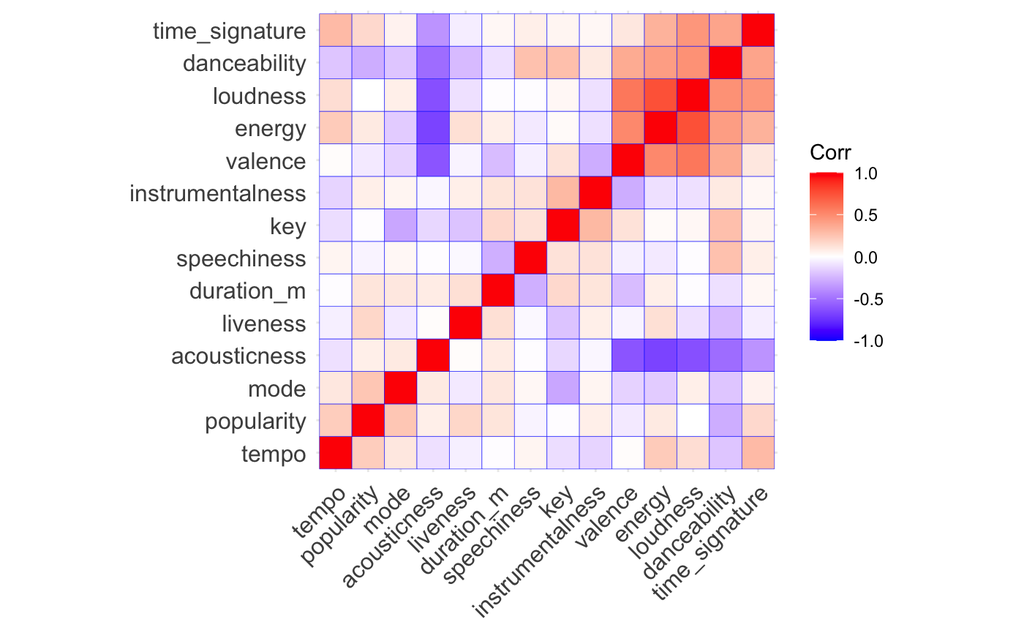

```r
ggcorrplot(cor, hc.order =TRUE,
           outline.color ="blue")
```

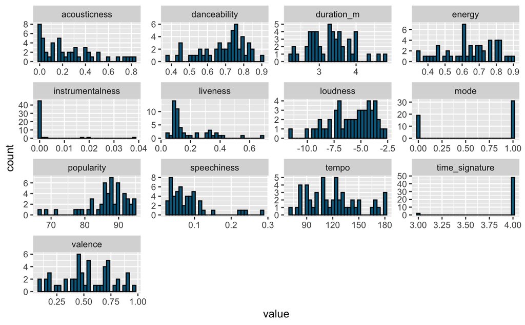

```r
library(purrr)

g=spotify %>%
  keep(is.numeric) %>%
  gather() %>%
  ggplot(aes(value)) +
    facet_wrap(~ key, scales = "free") +
    geom_histogram(fill="deepskyblue4", col=I("black"))

g
```

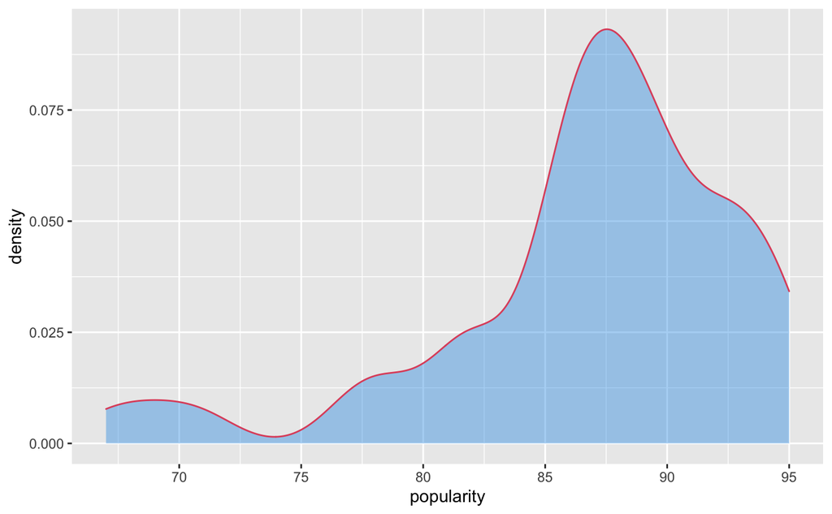

```r
ggplot(spotify, aes(x = popularity)) +
  geom_density(color = 2,
               fill = 4,
               alpha = 0.4)
```

```r
model = lm(popularity ~ ., data = spotify)
summary(model)
```

```
Call:
lm(formula = popularity ~ ., data = spotify)

Residuals:
     Min       1Q   Median       3Q      Max
-17.0512  -2.0532   0.6344   2.9833  11.7510

Coefficients:
                   Estimate Std. Error t value Pr(>|t|)
(Intercept)       3.842e+01  2.764e+01   1.390   0.1730
danceability     -2.049e+01  1.100e+01  -1.862   0.0708 .
energy            1.996e+01  1.173e+01   1.701   0.0975 .
key               2.983e-01  2.871e-01   1.039   0.3058
loudness         -7.529e-01  8.269e-01  -0.911   0.3686
mode              3.800e+00  2.152e+00   1.766   0.0859 .
speechiness       3.059e+00  1.787e+01   0.171   0.8651
acousticness      5.349e+00  6.188e+00   0.865   0.3930
instrumentalness  7.599e+01  1.628e+02   0.467   0.6435
liveness          2.966e+00  7.622e+00   0.389   0.6994
valence           2.884e+00  5.996e+00   0.481   0.6335
tempo            -2.238e-04  3.692e-02  -0.006   0.9952
duration_m       -4.743e-01  1.804e+00  -0.263   0.7941
time_signature    9.841e+00  5.743e+00   1.714   0.0952 .
---
Signif. codes:  0 ‘***’ 0.001 ‘**’ 0.01 ‘*’ 0.05 ‘.’ 0.1 ‘ ’ 1

Residual standard error: 6.167 on 36 degrees of freedom
Multiple R-squared:  0.2885,    Adjusted R-squared:  0.03155
F-statistic: 1.123 on 13 and 36 DF,  p-value: 0.3728
```

```r
#spotify %>% group_by(mode,key)
mode_1 = spotify[spotify$mode > 0, ]
mode_0 = spotify[spotify$mode == 0, ]
mode_1
```

| popularity | danceability | energy | key | loudness | mode | speechiness | acousticness | instrumentalness | liveness | valence | tempo | duration_m | time_signature |
| --- | --- | --- | --- | --- | --- | --- | --- | --- | --- | --- | --- | --- | --- |
| 95 | 0.563 | 0.664 | 9 | -5.044 | 1 | 0.1540 | 0.33500 | 0.00e+00 | 0.0849 | 0.6880 | 166.928 | 2.969117 | 4 |
| 94 | 0.761 | 0.525 | 11 | -6.900 | 1 | 0.0944 | 0.44000 | 6.70e-06 | 0.0921 | 0.5310 | 80.870 | 3.980083 | 4 |
| 94 | 0.644 | 0.648 | 1 | -4.601 | 1 | 0.1180 | 0.27600 | 0.00e+00 | 0.1350 | 0.4400 | 179.951 | 3.445167 | 4 |
| 93 | 0.514 | 0.730 | 1 | -5.934 | 1 | 0.0598 | 0.00146 | 9.54e-05 | 0.0897 | 0.3340 | 171.005 | 3.334000 | 4 |
| 93 | 0.664 | 0.609 | 1 | -6.509 | 1 | 0.0707 | 0.30400 | 0.00e+00 | 0.0926 | 0.1940 | 130.041 | 3.509333 | 4 |
| 92 | 0.561 | 0.431 | 10 | -8.810 | 1 | 0.0578 | 0.76800 | 1.42e-05 | 0.1060 | 0.1370 | 143.875 | 4.033550 | 4 |
| 92 | 0.591 | 0.764 | 1 | -5.484 | 1 | 0.0483 | 0.03830 | 0.00e+00 | 0.1030 | 0.4780 | 169.928 | 2.363433 | 4 |
| 92 | 0.380 | 0.339 | 3 | -7.885 | 1 | 0.0338 | 0.69100 | 0.00e+00 | 0.1200 | 0.0849 | 100.607 | 3.820450 | 4 |
| 92 | 0.612 | 0.807 | 10 | -2.810 | 1 | 0.0336 | 0.04950 | 1.77e-02 | 0.1010 | 0.3980 | 124.053 | 4.006667 | 4 |
| 90 | 0.677 | 0.696 | 0 | -6.181 | 1 | 0.1190 | 0.32100 | 0.00e+00 | 0.4200 | 0.4640 | 90.030 | 3.301367 | 4 |

[output cut: 21 more lines]

```r
mode_0
```

| popularity | danceability | energy | key | loudness | mode | speechiness | acousticness | instrumentalness | liveness | valence | tempo | duration_m | time_signature |
| --- | --- | --- | --- | --- | --- | --- | --- | --- | --- | --- | --- | --- | --- |
| 95 | 0.807 | 0.893 | 11 | -3.745 | 0 | 0.0347 | 0.04510 | 2.79e-05 | 0.3660 | 0.537 | 126.011 | 3.845783 | 4 |
| 95 | 0.824 | 0.764 | 5 | -4.175 | 0 | 0.0854 | 0.08880 | 2.94e-03 | 0.1170 | 0.881 | 107.998 | 2.877117 | 4 |
| 93 | 0.714 | 0.800 | 11 | -4.808 | 0 | 0.0504 | 0.12700 | 0.00e+00 | 0.3590 | 0.589 | 134.002 | 3.526000 | 4 |
| 90 | 0.593 | 0.503 | 8 | -6.725 | 0 | 0.2200 | 0.29300 | 0.00e+00 | 0.4050 | 0.710 | 178.781 | 2.295067 | 4 |
| 90 | 0.741 | 0.691 | 10 | -7.395 | 0 | 0.0672 | 0.02210 | 0.00e+00 | 0.0476 | 0.892 | 150.087 | 3.539217 | 4 |
| 89 | 0.702 | 0.825 | 6 | -3.787 | 0 | 0.0601 | 0.00883 | 0.00e+00 | 0.0674 | 0.915 | 102.977 | 3.384400 | 4 |
| 89 | 0.701 | 0.716 | 7 | -3.671 | 0 | 0.0361 | 0.17400 | 0.00e+00 | 0.3240 | 0.732 | 91.007 | 2.342217 | 4 |
| 88 | 0.798 | 0.620 | 8 | -7.079 | 0 | 0.2320 | 0.41400 | 1.92e-02 | 0.1120 | 0.235 | 120.031 | 2.733333 | 4 |
| 87 | 0.731 | 0.573 | 4 | -10.059 | 0 | 0.0544 | 0.40100 | 5.22e-05 | 0.1130 | 0.145 | 109.928 | 3.418167 | 4 |
| 87 | 0.653 | 0.524 | 11 | -9.016 | 0 | 0.0502 | 0.11200 | 0.00e+00 | 0.2030 | 0.553 | 83.970 | 2.669850 | 4 |

[output cut: 9 more lines]

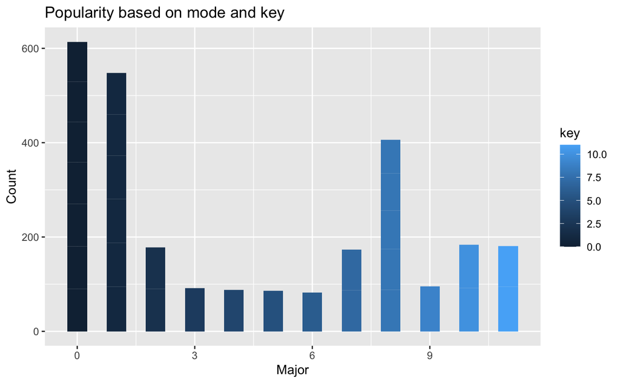

```r
ggplot(mode_1, aes(x = key, y = popularity, fill=key, width = 0.5)) +geom_bar(stat = "identity")+ggtitle("Popularity based on mode and key") + labs(y= "Count", x = "Major")
```

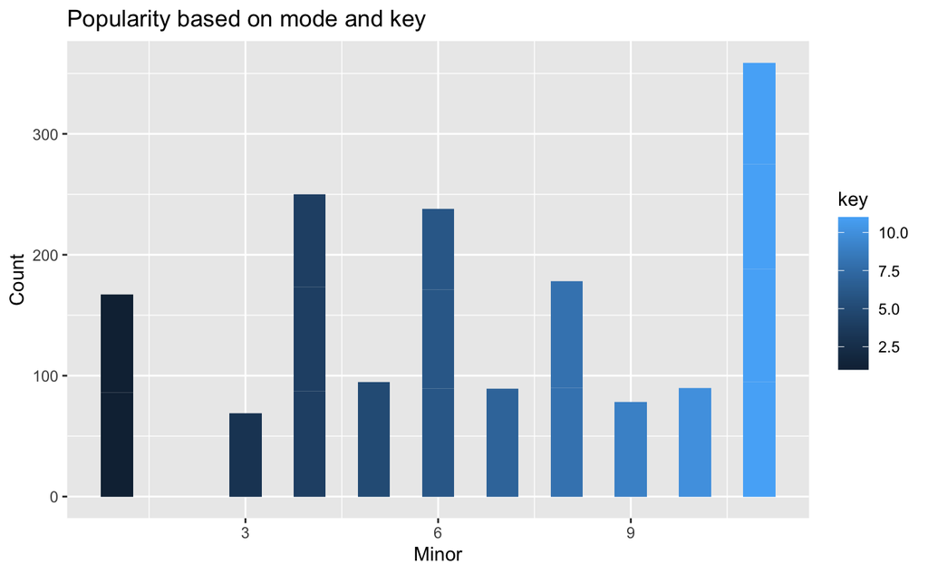

```r
ggplot(mode_0, aes(x = key, y = popularity, fill = key,width = 0.5)) +geom_bar(stat = "identity")+ggtitle("Popularity based on mode and key")+ labs(y= "Count", x = "Minor")
```

```r
df1= spotify %>% select(popularity,valence, energy, loudness, danceability, acousticness)
df1
```

| popularity | valence | energy | loudness | danceability | acousticness |
| --- | --- | --- | --- | --- | --- |
| 95 | 0.6880 | 0.664 | -5.044 | 0.563 | 0.33500 |
| 95 | 0.5370 | 0.893 | -3.745 | 0.807 | 0.04510 |
| 95 | 0.8810 | 0.764 | -4.175 | 0.824 | 0.08880 |
| 94 | 0.5310 | 0.525 | -6.900 | 0.761 | 0.44000 |
| 94 | 0.4400 | 0.648 | -4.601 | 0.644 | 0.27600 |
| 93 | 0.3340 | 0.730 | -5.934 | 0.514 | 0.00146 |
| 93 | 0.5890 | 0.800 | -4.808 | 0.714 | 0.12700 |
| 93 | 0.1940 | 0.609 | -6.509 | 0.664 | 0.30400 |
| 92 | 0.1370 | 0.431 | -8.810 | 0.561 | 0.76800 |
| 92 | 0.4780 | 0.764 | -5.484 | 0.591 | 0.03830 |

[output cut: 40 more lines]

```r
NA
```

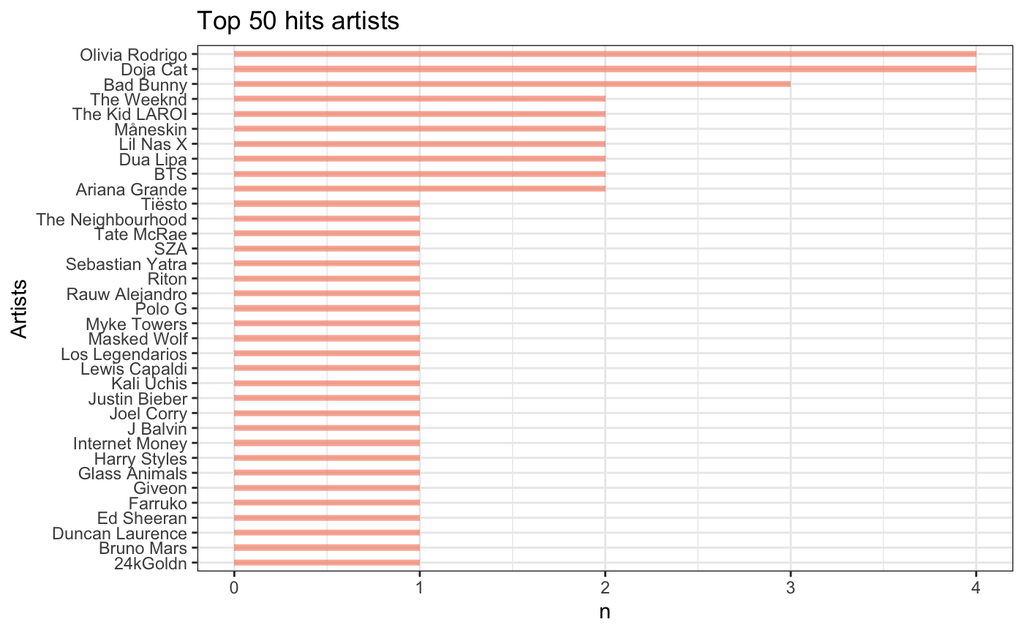

```r
library(reshape2)
df = spotify_df %>% count(artist_name, sort = TRUE)
df %>% ggplot(aes(x=reorder(artist_name, n), y=n)) +
  geom_bar(stat="identity", fill="#f68060", alpha=.6, width=.4) +
  coord_flip() +
  xlab("Artists") +
  theme_bw() + ggtitle("Top 50 hits artists")
```

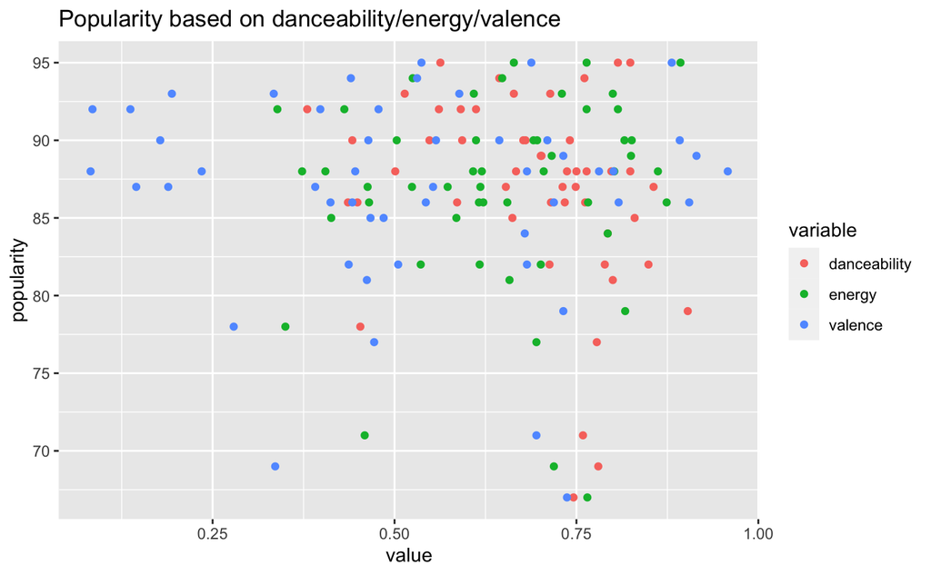

```r
library(ggExtra)
library(hrbrthemes)
library(viridisLite)
df2 = df1 %>% select(popularity,danceability,energy,valence)
df2=melt(df2, id.vars = 'popularity')
ggplot(df2, aes(x=value, y=popularity, color = variable))+geom_point()+ ggtitle("Popularity based on danceability/energy/valence")
```

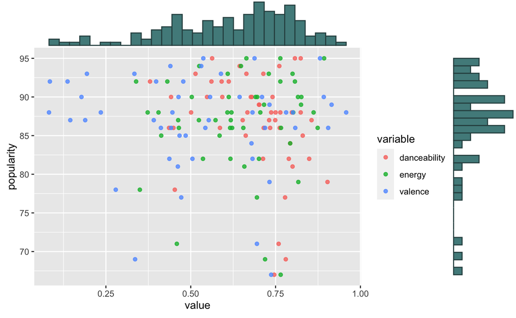

```r
p1 = ggplot(df2, aes(value, popularity, color = variable)) + geom_point(alpha=0.8)
ggMarginal(p1, type = "histogram", fill = "darkslategray4", color = 'darkslategray')
```

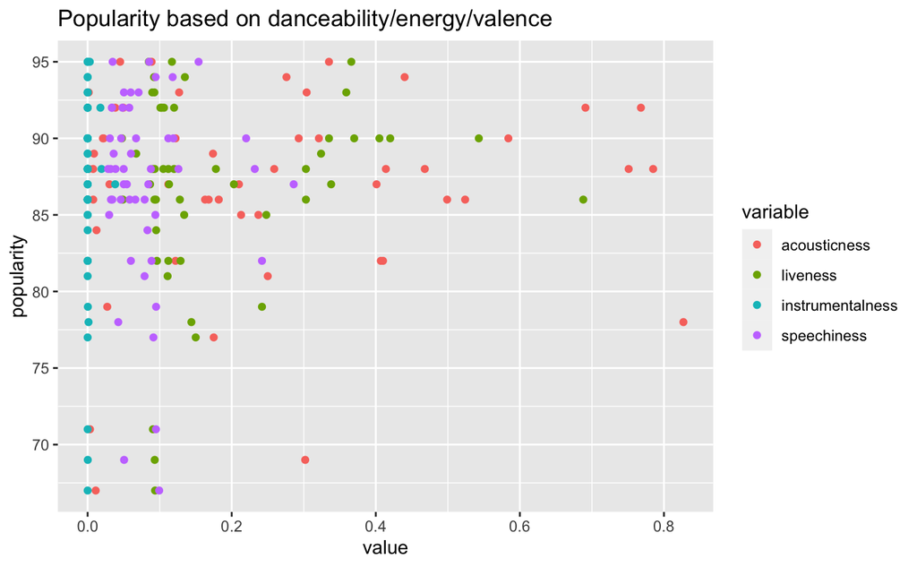

```r
#p2 <- ggplot(data=df2, aes(x=value, group=variable, fill=variable)) +
    #geom_density(adjust=1.5, alpha=.4) +
    #theme_ipsum()

df3 = spotify %>% select(popularity,acousticness,liveness,instrumentalness,speechiness)
df3=melt(df3, id.vars = 'popularity')
ggplot(df3, aes(x=value, y=popularity, color = variable))+geom_point()+ ggtitle("Popularity based on danceability/energy/valence")
```

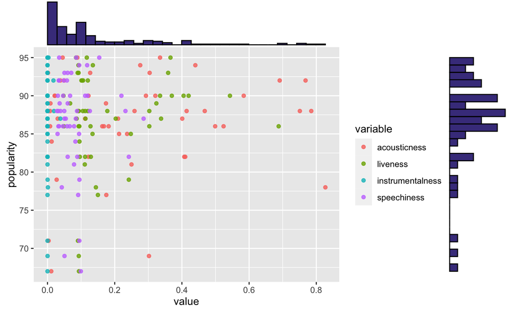

```r
p2 = ggplot(df3, aes(value, popularity, color = variable)) + geom_point(alpha=0.8)
ggMarginal(p2, type = "histogram", fill = "darkslateblue", color = 'black')
```

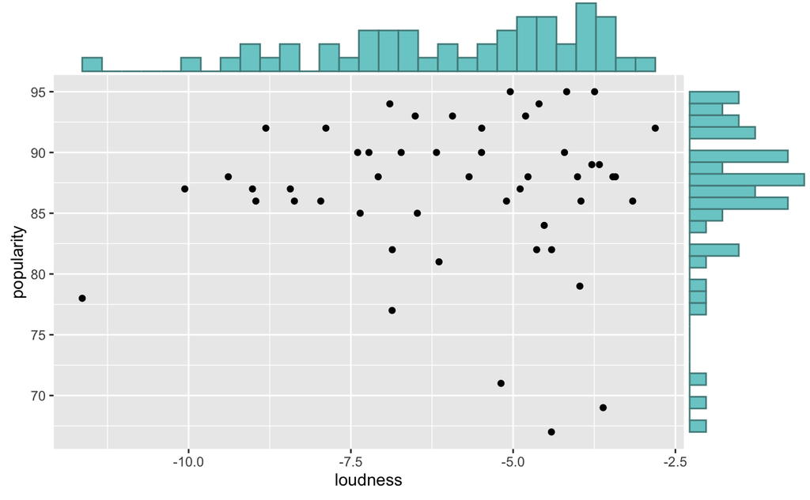

```r
#ggplot(df3, aes(x = value, y = popularity, color = variable)) + geom_line()

#gg <- ggplot(df3)
#gg <- gg + geom_bar(aes(x =value , y = popularity, fill = variable), stat = "identity")
#gg <- gg + scale_x_continuous(breaks=c(1:10))
#gg <- gg + facet_wrap(~variable)
#print(gg)
#df4 = spotify %>% select(popularity,acousticness,liveness)
#ggplot(df3, aes(x=value, y=popularity, group=variable, color=variable)) + geom_line()

p = ggplot(spotify, aes(loudness, popularity)) + geom_point(alpha=1)
ggMarginal(p, type = "histogram", fill = "darkslategray3", color = 'darkslategray4')
```

```r
summary(spotify$duration_m)
```

```
   Min. 1st Qu.  Median    Mean 3rd Qu.    Max.
  2.213   2.873   3.312   3.291   3.593   4.785
```

```r
summary(spotify$tempo)
```

```
   Min. 1st Qu.  Median    Mean 3rd Qu.    Max.
  72.02   98.66  120.52  121.08  138.53  180.92
```

```r
summary(spotify$time_signature)
```

```
   Min. 1st Qu.  Median    Mean 3rd Qu.    Max.
   3.00    4.00    4.00    3.96    4.00    4.00
```